# Principios y Prácticas de SEM y MLM (5ed)

Tema 3.2 Full SEM

Author

Affiliation

Efraín García Sánchez

CIMCYC — Universidad de Granada

Published

May 15, 2026

# Principios: Full SEM

## Recordar

- $Calidad_{Modelo} = Calidad_{Ideas}$
- $Modelo_{SEM} = Modelo_{Medición} + Modelo_{Structural}$
- $Modelo_{SEM} \neq {Modelo_{Mejorado}}$

> “structural equation modeling (SEM) refers to a set of statistical techniques for estimating the magnitudes and directions of presumed causal effects in quantitative studies based on cross-sectional, longitudinal, experimental, or other kinds of research designs.” (Kline, 2023, p. 10)

## Tipos de Modelos SEM

- “Parametric or Traditional SEM”
  - Más supuestos (e.g., continuas)
  - *Mixture models* (e.g., clases)
  - Más explicativos

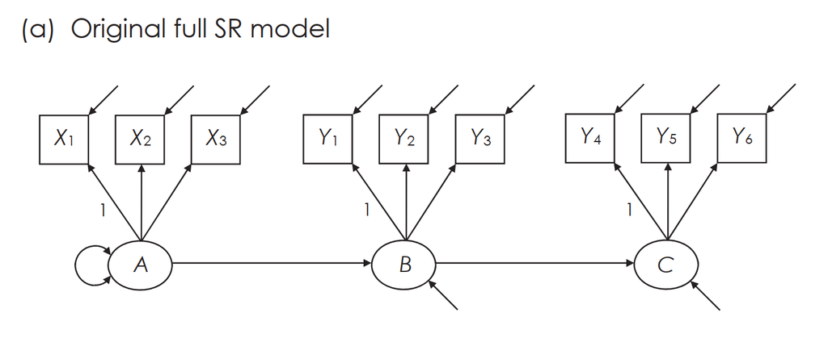

- “Composite or PLS-SEM”
  - Menos supuestos
  - Menos muestra
  - Más predictivos

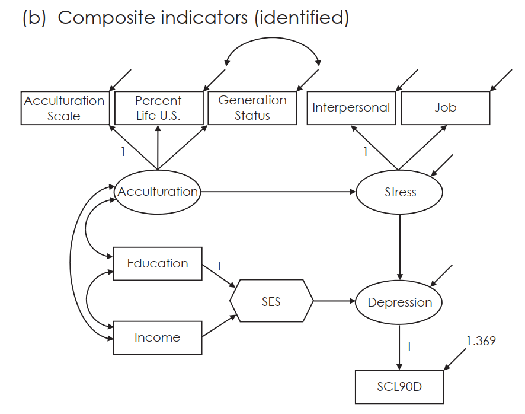

- “Nonparametric SEM or Causal Structural Model”
  - Más teoría
  - Menos supuestos estadísticos
  - Inferencia Causal

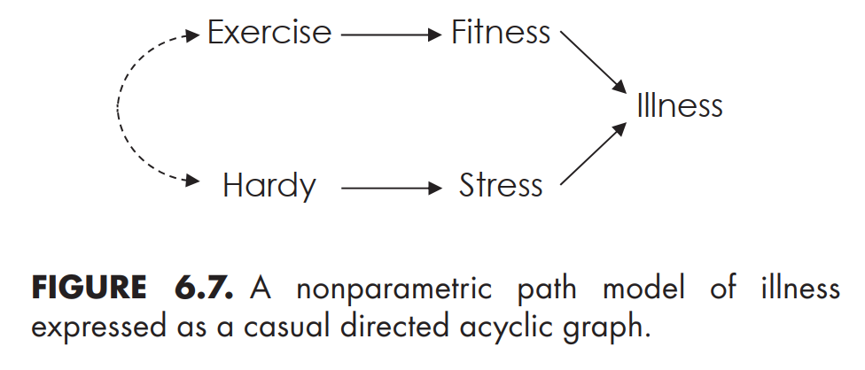

# Prácticas

## Práctica: Full SEM

- Probar el efecto de comportamientos alimenticios **no saludables** y el consumo de **sustancias** sobre el **Bienestar**
- Modelo de SEM completo (medición + estructural) con datos de salud mental

**Variable Dependiente:**

- Wellbeing: ment_health + phys_health + social_connect + sleep_quality

**Variables Predictoras**

- Consumo de sustancias (substances): caffeine_non_exam + alcohol_freq + nicotine_freq
- Comportamientos alimenticios no saludables (eat_unhealthy): eat_processed_meat + eat_convenience_food + eat_fast_food

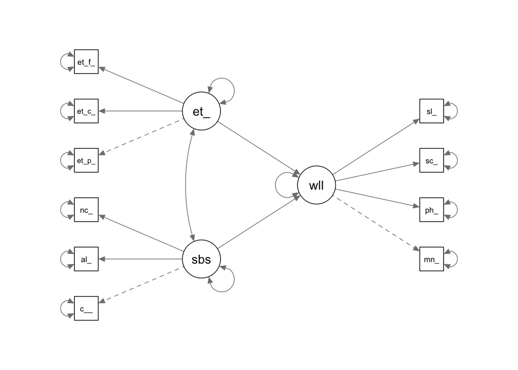

## Preparar el ambiente de trabajo

- Cargar los paquetes

```r
library(tidyverse)
library(easystats)
library(lavaanExtra)  # para formatode salida de lavaan
library(tidySEM)      # para formatode salida de lavaan
library(lavaan)       # Para modelos SEM
library(semTools)     # Para fiabilidad y otros relacionadas con SEM
library(semPlot)      # Para visualizar modelos SEM
```

## Importar los datos: solo numéricos (recomendado para evitar conflictos con paquetes)

```r
data <- readr::read_csv(
  here::here("data",
  "northampton_student_health_data_package",
  "northampton_student_health_numeric.csv"))

glimpse(data)
```

```
Rows: 590
Columns: 61
$ id                             <dbl> 1, 2, 3, 4, 5, 6, 7, 8, 9, 10, 11, 12, …
$ age_group                      <dbl> 1, 1, 1, 1, 1, 1, 2, 4, 1, 1, 1, 1, 1, …
$ gender                         <dbl> 2, 1, 1, 1, 1, 2, 1, 1, 2, 2, 2, 2, 2, …
$ sexual_orientation             <dbl> 1, 2, 1, 3, 1, 1, 1, 1, 1, 1, 1, 1, 1, …
$ ethnicity                      <dbl> 1, 1, 1, 2, 1, 3, 1, 1, 1, 3, 1, 1, 1, …
$ study_mode                     <dbl> 1, 1, 1, 1, 1, 1, 1, 2, 1, 1, 1, 1, 1, …
$ study_level                    <dbl> 3, 3, 3, 3, 2, 6, 4, 3, 1, 2, 1, 1, 1, …
$ living_situation               <dbl> 1, 2, 1, 3, 2, 4, 3, 3, 1, 2, 4, 1, 1, …
$ phys_health                    <dbl> 3, 4, 4, 3, 4, 5, 5, 1, 4, 4, 4, 5, 5, …
$ ment_health                    <dbl> 4, 3, 2, 4, 3, 3, 2, 1, 4, 4, 3, 5, 3, …
$ social_connect                 <dbl> 4, 3, 1, 1, 2, 3, 2, 4, 4, 3, 3, 3, 2, …
$ sitting_weekday_hours          <dbl> 8, 5, 7, 9, NA, 5, 11, 13, 6, 5, 12, 6,…
$ sleep_quality                  <dbl> 8, 7, 4, 7, 2, 5, 3, 8, 7, 2, 9, 7, 3, …
```

[output cut: 48 more lines]

## Preparar los datos

```r
data <- data |>
  mutate(# creo variable dummy para género (Female vs Male)
         gender_female = case_when(gender == 1 ~ 1, # Female
                                   gender == 2 ~ 0, # Male
                                   .default = NULL),
         # creo una variable de etnia para los grupos más grandes
         ethnicity_cat = case_when(ethnicity == 1 ~ "White",
                                 ethnicity == 3 ~ "Black",
                                 ethnicity == 4 ~ "Asian",
                                 TRUE ~ NA_character_),
         # ordeno la variable de etnia en niveles (White es la referencia)
         ethnicity_cat = factor(ethnicity_cat,
                                levels = c("White", "Black", "Asian")),
         # Creo una variable dummy para ver diferencias con White
         ethnicity_black = ifelse(test = ethnicity_cat == "Black",
                                  yes = 1, no = 0),
         ethnicity_asian = ifelse(test = ethnicity_cat == "Asian",
                                  yes = 1, no = 0),
         # creo una variable categórica con pa_activity
         pa_activity_level_cat = case_when(pa_activity_level == 0 ~ "0_Inactive",
                                       pa_activity_level == 1 ~ "1_Fairly_Active",
                                       pa_activity_level == 2 ~ "2_Active")
         )
```

## Especificar el modelo

```r
m1 <- '
  # Modelo de medición
  wellbeing =~ ment_health + phys_health + social_connect + sleep_quality
  substances =~ caffeine_non_exam + alcohol_freq + nicotine_freq
  eat_unhealthy =~ eat_processed_meat + eat_convenience_food + eat_fast_food

  # Modelo estructural
  wellbeing ~ substances + eat_unhealthy
'
```

## Estimar el modelo

```r
m1_fit <- lavaan::sem(
  model = m1,
  estimator = "ML",
  data = data)
```

## Evaluar el modelo

```r
summary(m1_fit,
        standardized = TRUE,
        ci = TRUE,
        fit.measures = TRUE)
```

```
lavaan 0.6-21 ended normally after 51 iterations

  Estimator                                         ML
  Optimization method                           NLMINB
  Number of model parameters                        23

  Number of observations                           590

Model Test User Model:

  Test statistic                                87.753
  Degrees of freedom                                32
  P-value (Chi-square)                           0.000

Model Test Baseline Model:

  Test statistic                               920.954
  Degrees of freedom                                45
  P-value                                        0.000

User Model versus Baseline Model:

  Comparative Fit Index (CFI)                    0.936
  Tucker-Lewis Index (TLI)                       0.910

Loglikelihood and Information Criteria:

  Loglikelihood user model (H0)             -10327.752
  Loglikelihood unrestricted model (H1)     -10283.875

  Akaike (AIC)                               20701.504
  Bayesian (BIC)                             20802.247
  Sample-size adjusted Bayesian (SABIC)      20729.229

Root Mean Square Error of Approximation:

  RMSEA                                          0.054
  90 Percent confidence interval - lower         0.041
  90 Percent confidence interval - upper         0.068
  P-value H_0: RMSEA <= 0.050                    0.281
```

[output cut: 74 more lines]

```
    eat_unhealthy     0.603    0.119    5.056    0.000    0.369    0.837
   Std.lv  Std.all
    0.238    0.214
    0.495    0.650
    0.749    0.749
    3.161    0.779
    5.337    0.866
    2.563    0.887
    4.024    0.602
    2.037    0.772
    0.943    0.483
    0.774    0.524
    0.835    0.835
    1.000    1.000
    1.000    1.000
```

## Evaluar el modelo

```r
lavaan::fitmeasures(m1_fit,
                    output = "text")
```

```
Model Test User Model:

  Test statistic                                87.753
  Degrees of freedom                                32
  P-value                                        0.000

Model Test Baseline Model:

  Test statistic                               920.954
  Degrees of freedom                                45
  P-value                                        0.000

User Model versus Baseline Model:

  Comparative Fit Index (CFI)                    0.936
  Tucker-Lewis Index (TLI)                       0.910
  Bentler-Bonett Non-normed Fit Index (NNFI)     0.910
  Bentler-Bonett Normed Fit Index (NFI)          0.905
  Parsimony Normed Fit Index (PNFI)              0.643
  Bollen's Relative Fit Index (RFI)              0.866
  Bollen's Incremental Fit Index (IFI)           0.937
  Relative Noncentrality Index (RNI)             0.936

Loglikelihood and Information Criteria:

  Loglikelihood user model (H0)             -10327.752
  Loglikelihood unrestricted model (H1)     -10283.875

  Akaike (AIC)                               20701.504
  Bayesian (BIC)                             20802.247
  Sample-size adjusted Bayesian (SABIC)      20729.229

Root Mean Square Error of Approximation:

  RMSEA                                          0.054
  90 Percent confidence interval - lower         0.041
  90 Percent confidence interval - upper         0.068
  P-value H_0: RMSEA <= 0.050                    0.281
  P-value H_0: RMSEA >= 0.080                    0.001

Standardized Root Mean Square Residual:

  RMR                                            0.107
  RMR (No Mean)                                  0.107
  SRMR                                           0.046

Other Fit Indices:

  Hoelter Critical N (CN) alpha = 0.05         311.582
  Hoelter Critical N (CN) alpha = 0.01         360.606

  Goodness of Fit Index (GFI)                    0.973
  Adjusted Goodness of Fit Index (AGFI)          0.953
  Parsimony Goodness of Fit Index (PGFI)         0.566

  McDonald Fit Index (MFI)                       0.954

  Expected Cross-Validation Index (ECVI)         0.227
```

## Reportar el modelo

```r
parameters::parameters(m1_fit,
            ci = 0.95,
            standardize = TRUE)
```

```
# Loading

Link                                  | Coefficient |   SE |       95% CI
-------------------------------------------------------------------------
wellbeing =~ ment_health              |        0.89 | 0.03 | [0.82, 0.95]
wellbeing =~ phys_health              |        0.59 | 0.03 | [0.52, 0.66]
wellbeing =~ social_connect           |        0.50 | 0.04 | [0.43, 0.57]
wellbeing =~ sleep_quality            |        0.47 | 0.04 | [0.40, 0.54]
substances =~ caffeine_non_exam       |        0.37 | 0.06 | [0.26, 0.48]
substances =~ alcohol_freq            |        0.34 | 0.06 | [0.23, 0.45]
substances =~ nicotine_freq           |        0.63 | 0.07 | [0.49, 0.77]
eat_unhealthy =~ eat_processed_meat   |        0.48 | 0.04 | [0.40, 0.56]
eat_unhealthy =~ eat_convenience_food |        0.72 | 0.04 | [0.64, 0.80]
eat_unhealthy =~ eat_fast_food        |        0.69 | 0.04 | [0.61, 0.77]

Link                                  |     z |      p
------------------------------------------------------
wellbeing =~ ment_health              | 28.26 | < .001
wellbeing =~ phys_health              | 17.18 | < .001
wellbeing =~ social_connect           | 13.60 | < .001
wellbeing =~ sleep_quality            | 12.47 | < .001
substances =~ caffeine_non_exam       |  6.50 | < .001
substances =~ alcohol_freq            |  6.02 | < .001
substances =~ nicotine_freq           |  9.01 | < .001
eat_unhealthy =~ eat_processed_meat   | 11.45 | < .001
eat_unhealthy =~ eat_convenience_food | 16.75 | < .001
eat_unhealthy =~ eat_fast_food        | 16.24 | < .001

# Regression

Link                      | Coefficient |   SE |         95% CI |     z |      p
--------------------------------------------------------------------------------
wellbeing ~ substances    |       -0.37 | 0.07 | [-0.51, -0.23] | -5.29 | < .001
wellbeing ~ eat_unhealthy |       -0.09 | 0.06 | [-0.21,  0.03] | -1.48 | 0.138

# Correlation

Link                        | Coefficient |   SE |       95% CI |    z |      p
-------------------------------------------------------------------------------
substances ~~ eat_unhealthy |        0.30 | 0.07 | [0.16, 0.44] | 4.31 | < .001
```

## Representar el modelo estructural + medición

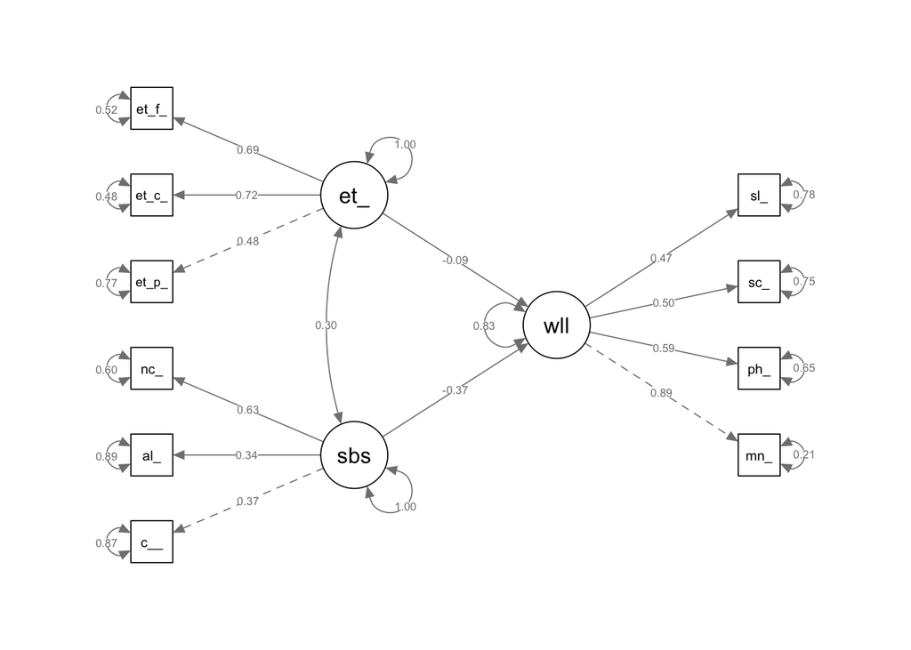

```r
semPlot::semPaths(m1_fit,
                  whatLabels = "std",
                  rotation = 2,
                  layout = "tree2")
```

# Ejercicio: Full SEM

## Ejercicio: Full SEM

- Replicar el ejercicio anterior con las siguientes variaciones:
  - Usar *eat_healthy* como variable predictora (*eat_fruit + eat_vegetables + eat_calcium*)
  - Adicionar covariables al modelo prediciendo “*wellbeing*”: *gender_female*, *age_group*
- Especificar el modelo
- Estimar el modelo
- Evaluar el modelo

# Escribir tu respuesta aquí

# Principios: Mediación

## Análisis de mediación

- Modelo estadístico que evalúa
  - si la relación entre dos variables (*X*-*Y*) se explica por una tercera variable mediadora (*M*)
  - el efecto **indirecto** de una variable *X* sobre otra *Y* a través de *M*.

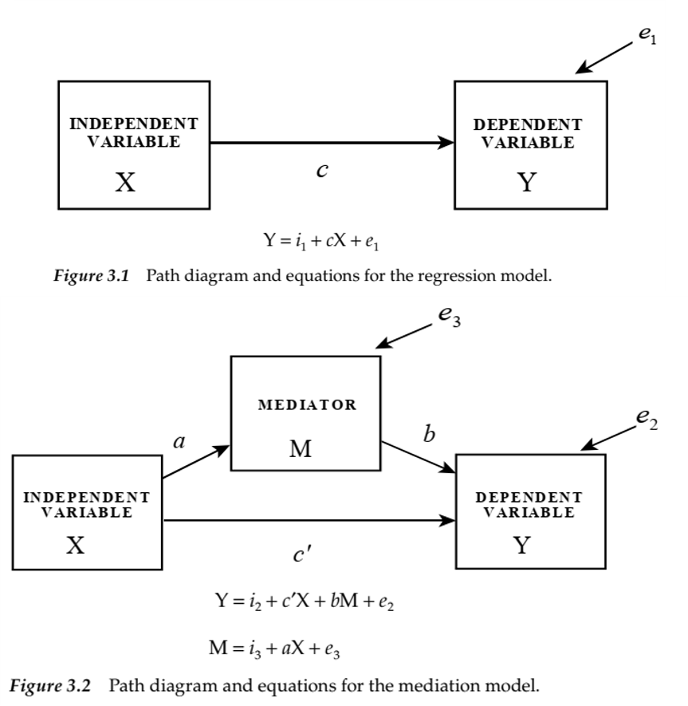

## ¿Cuándo se usan los análisis de mediación?

- Preguntas de investigación
  - ¿Por qué sucede *Y*?
  - ¿Cómo influye *X* sobre *Y* a través de *M*?
  - ¿Cuál es el mecanismo o proceso (*M*) a través del cual sucede la relación entre X y Y?
- Mediación [(MacKinnon, 2008)](https://www.taylorfrancis.com/books/mono/10.4324/9780203809556/introduction-statistical-mediation-analysis-david-mackinnon)
  - *Action theory*: *VI* cambia la *M*
  - *Conceptal theory*: *M* causa *Y*

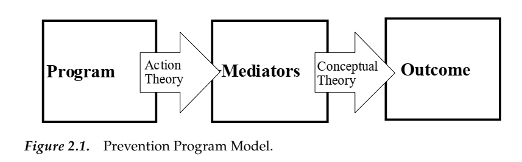

## ¿Cuándo se usan los análisis de mediación?

- Preguntas de mecanismos causales o de proceso
  - Diseños: experimentales, longitudinales, etc.
  - Teoría: Plausibilidad, evidencia previa, etc.
- Búsqueda de caminos o posibles mecanismos
  - Efectos indirectos (vs. mediación)
- *¿Análisis de mediación con datos correlacionales?*
  - Control de variables (e.g., confounders)
  - Variables instrumentales (e.g., natural experiments)
- ¿Análisis de mediación o efectos indirectos?
  - Mediación -> Causalidad (Teoría + Diseño)
  - Efectos indirectos -> Plausibilidad (Teoría)

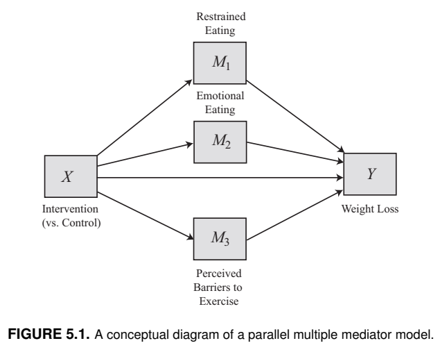

## Tipos de mediación

- Número de mediadoras
  - Mediación simple
  - Mediación paralela
  - Mediación serial
- “Grado de mediación”
  - Total: M explica la totalidad de la relación entre X-Y
  - Parcial: M explica una parte de la relación entre X-Y
  - Crítica de Hayes (2022)
    - Puede haber efectos indirectos en ausencia de efectos totales
    - Existen mecanismos (o variables) omitidas/alternativas
    - “Superioridad” de la mediación total (vs. parcial)
    - *Mispecification* de la mediación parcial ()

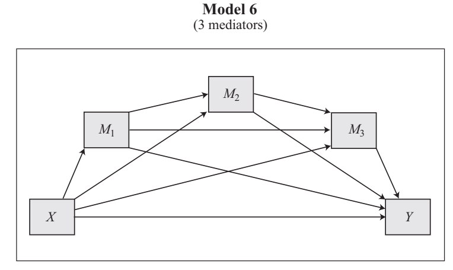

## ¿Cómo se representa una mediación?

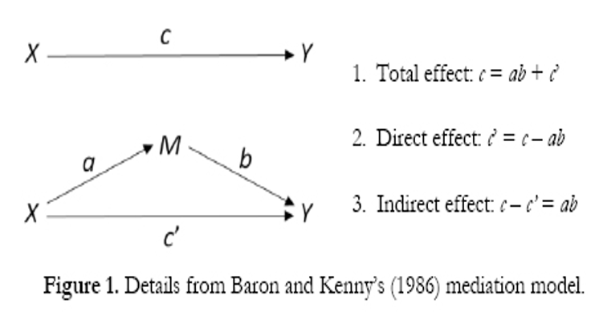

## Interpretación de la mediación

- **Efecto directo** (c’)
  - El efecto de *X* sobre *Y*, manteniendo constante *M*
  - La diferencia en *Y* por cada unidad que aumenta *X*, controlando por *M*
- **Efecto indirecto** (*ab*)
  - El efecto de X sobre *Y*, como resultado del efecto de *X* sobre *M*, que a su vez afecta *Y* ($ab = c - c’$)
  - La diferencia estimada en Y en X, como resultado del efecto de X sobre M, que a su vez afecta Y
- **Efecto total** (c)
  - El efecto de X sobre Y ($c = c’+ a*b$)
  - La diferencia en Y por cada unidad que aumenta X

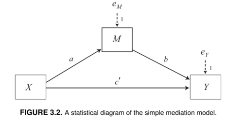

## Tener en cuenta en el análisis de mediación

- Problemas con la Teoría Normal (*Normal Theory approach*)
  - Efecto indirecto viola la distribución de muestreo de **a*b**
  - Menos preciso en estimar los intérvalos de confianza
- Alternativas
  - Test de Sobel (prueba si el efecto indirecto es diferente de cero)
  - Bootstrapping (para estimar intérvalos de confianza)
  - Interpretación: Los intérvalos de confianza no deben cruzar el cero.
- NOTA: El bootstrapping…
  - No compensa el tamaño de la muestra
  - Reproduce el sesgo (si la muestra es mediocre)
  - Sensible a outliers y valores extremos (muestras pequeñas)
  - Entre 5.000 y 10.000 es suficiente

# Práctica: Mediación con modelos SEM

## Especificar el modelo

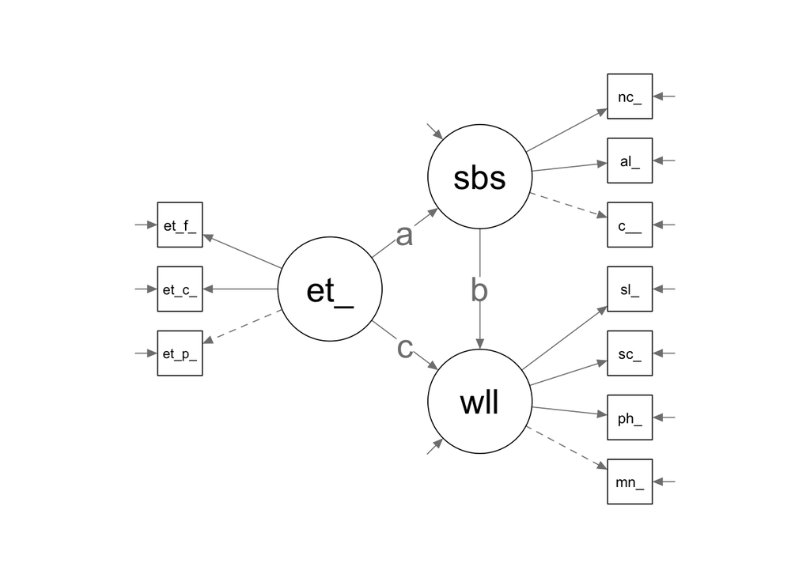

## Especificar el modelo

```r
m2 <- '
  # Modelo de medición
  wellbeing =~ ment_health + phys_health + social_connect + sleep_quality
  substances =~ caffeine_non_exam + alcohol_freq + nicotine_freq
  eat_unhealthy =~ eat_processed_meat + eat_convenience_food + eat_fast_food

  # Modelo estructural
  substances ~ a*eat_unhealthy
  wellbeing ~ b*substances + c*eat_unhealthy

  # Efecto indirecto
  indirecto:= a*b
  directo := c
  total := a*b + c

  # Tamaño del efecto indirecto (de forma descriptiva, pero inestables)
  proporcion := indirecto/total # cuánto del efecto *total* es por el indirecto
  ratio := indirecto/directo    # cuánto es el efecto indirecto en relación al
'
```

## Estimar el modelo

```r
m2_fit <- lavaan::sem(
  model = m2,
   bootstrap = 100L, # aumentar a 1000 o 5000 para resultados más estables
   test = "bootstrap",
  data = data)
```

## Evaluar el modelo

```r
summary(m2_fit,
        std = TRUE,
        ci = TRUE,
        fit.measures = TRUE)
```

```
lavaan 0.6-21 ended normally after 51 iterations

  Estimator                                         ML
  Optimization method                           NLMINB
  Number of model parameters                        23

  Number of observations                           590

Model Test User Model:

  Test statistic                                87.753
  Degrees of freedom                                32
  P-value (Chi-square)                           0.000

  Test statistic                                87.753
  Degrees of freedom                                32
  P-value (Bollen-Stine bootstrap)               0.000

Model Test Baseline Model:

  Test statistic                               920.954
  Degrees of freedom                                45
  P-value                                        0.000

User Model versus Baseline Model:

  Comparative Fit Index (CFI)                    0.936
  Tucker-Lewis Index (TLI)                       0.910

Loglikelihood and Information Criteria:

  Loglikelihood user model (H0)             -10327.752
  Loglikelihood unrestricted model (H1)     -10283.875

  Akaike (AIC)                               20701.504
  Bayesian (BIC)                             20802.247
  Sample-size adjusted Bayesian (SABIC)      20729.229

Root Mean Square Error of Approximation:

```

[output cut: 88 more lines]

```
    1.000    1.000

Defined Parameters:
                   Estimate  Std.Err  z-value  P(>|z|) ci.lower ci.upper
    indirecto        -0.134    0.045   -2.966    0.003   -0.222   -0.045
    directo          -0.108    0.074   -1.465    0.143   -0.253    0.037
    total            -0.242    0.068   -3.541    0.000   -0.376   -0.108
    proporcion        0.553    0.217    2.543    0.011    0.127    0.979
    ratio             1.237    1.088    1.137    0.256   -0.896    3.370
   Std.lv  Std.all
   -0.111   -0.111
   -0.090   -0.090
   -0.202   -0.202
    0.553    0.553
    1.237    1.237
```

## Evaluar el modelo

```r
lavaan::fitmeasures(m2_fit,
                    output = "text")
```

```
Model Test User Model:

  Test statistic                                87.753
  Degrees of freedom                                32
  P-value                                        0.000

Model Test Baseline Model:

  Test statistic                               920.954
  Degrees of freedom                                45
  P-value                                        0.000

User Model versus Baseline Model:

  Comparative Fit Index (CFI)                    0.936
  Tucker-Lewis Index (TLI)                       0.910
  Bentler-Bonett Non-normed Fit Index (NNFI)     0.910
  Bentler-Bonett Normed Fit Index (NFI)          0.905
  Parsimony Normed Fit Index (PNFI)              0.643
  Bollen's Relative Fit Index (RFI)              0.866
  Bollen's Incremental Fit Index (IFI)           0.937
  Relative Noncentrality Index (RNI)             0.936

Loglikelihood and Information Criteria:

  Loglikelihood user model (H0)             -10327.752
  Loglikelihood unrestricted model (H1)     -10283.875

  Akaike (AIC)                               20701.504
  Bayesian (BIC)                             20802.247
  Sample-size adjusted Bayesian (SABIC)      20729.229

Root Mean Square Error of Approximation:

  RMSEA                                          0.054
  90 Percent confidence interval - lower         0.041
  90 Percent confidence interval - upper         0.068
  P-value H_0: RMSEA <= 0.050                    0.281
  P-value H_0: RMSEA >= 0.080                    0.001

Standardized Root Mean Square Residual:

  RMR                                            0.107
  RMR (No Mean)                                  0.107
  SRMR                                           0.046

Other Fit Indices:

  Hoelter Critical N (CN) alpha = 0.05         311.582
  Hoelter Critical N (CN) alpha = 0.01         360.606

  Goodness of Fit Index (GFI)                    0.973
  Adjusted Goodness of Fit Index (AGFI)          0.953
  Parsimony Goodness of Fit Index (PGFI)         0.566

  McDonald Fit Index (MFI)                       0.954

  Expected Cross-Validation Index (ECVI)         0.227
```

## Reportar el modelo

```r
parameters::parameters(m2_fit,
            ci = 0.95,
            standardize = TRUE) |>
  display()
```

# Loading

| Link | Coefficient | SE | 95% CI | z | p |
| --- | --- | --- | --- | --- | --- |
| wellbeing =~ ment_health | 0.89 | 0.03 | (0.82, 0.95) | 28.26 | < .001 |
| wellbeing =~ phys_health | 0.59 | 0.03 | (0.52, 0.66) | 17.18 | < .001 |
| wellbeing =~ social_connect | 0.50 | 0.04 | (0.43, 0.57) | 13.60 | < .001 |
| wellbeing =~ sleep_quality | 0.47 | 0.04 | (0.40, 0.54) | 12.47 | < .001 |
| substances =~ caffeine_non_exam | 0.37 | 0.06 | (0.26, 0.48) | 6.50 | < .001 |
| substances =~ alcohol_freq | 0.34 | 0.06 | (0.23, 0.45) | 6.02 | < .001 |
| substances =~ nicotine_freq | 0.63 | 0.07 | (0.49, 0.77) | 9.01 | < .001 |
| eat_unhealthy =~ eat_processed_meat | 0.48 | 0.04 | (0.40, 0.56) | 11.45 | < .001 |
| eat_unhealthy =~ eat_convenience_food | 0.72 | 0.04 | (0.64, 0.80) | 16.75 | < .001 |
| eat_unhealthy =~ eat_fast_food | 0.69 | 0.04 | (0.61, 0.77) | 16.24 | < .001 |

# Regression

| Link | Coefficient | SE | 95% CI | z | p |
| --- | --- | --- | --- | --- | --- |
| substances ~ eat_unhealthy (a) | 0.30 | 0.07 | (0.16, 0.44) | 4.31 | < .001 |
| wellbeing ~ substances (b) | -0.37 | 0.07 | (-0.51, -0.23) | -5.29 | < .001 |
| wellbeing ~ eat_unhealthy (c) | -0.09 | 0.06 | (-0.21, 0.03) | -1.48 | 0.138 |

# Defined

| To | Coefficient | SE | 95% CI | z | p |
| --- | --- | --- | --- | --- | --- |
| (indirecto) | -0.11 | 0.04 | (-0.18, -0.04) | -3.12 | 0.002 |
| (directo) | -0.09 | 0.06 | (-0.21, 0.03) | -1.48 | 0.138 |
| (total) | -0.20 | 0.05 | (-0.31, -0.10) | -3.81 | < .001 |
| (proporcion) | 0.55 | 0.22 | (0.13, 0.98) | 2.54 | 0.011 |
| (ratio) | 1.24 | 1.09 | (-0.90, 3.37) | 1.14 | 0.256 |

## Representar el modelo estructural + medición

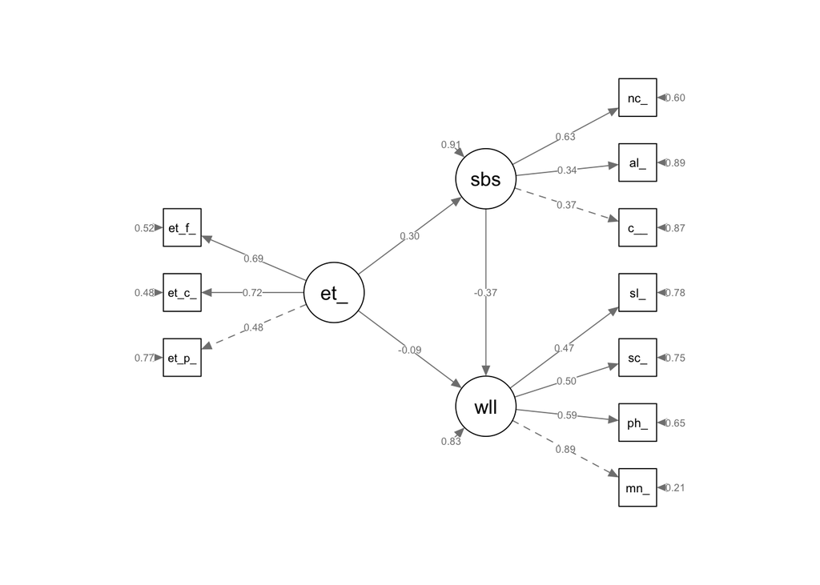

```r
semPlot::semPaths(m2_fit,
                  whatLabels = "std",
                  style = "lisrel",
                  rotation = 2,
                  layout = "tree2"
                  )
```

# Ejercicio

## Ejercicio: Mediación con SEM

- Probar la mediación usando *eat_healthy* como predictora del consumo de sustancias
  - *eat_healthy =~ eat_fruit + eat_vegetables + eat_calcium*
- Replicar el ejercicio anterior con las siguientes variaciones:
  - Usar *eat_healthy* como predictora
  - Usar *substances* como mediadora
  - Usar *wellbeing* como resultado
  - Controlar por covariables en wellbeing (*gender_female*, *age_group*)
- Estimar el efecto indirecto de **eat_healthy** sobre **wellbeing** a través de **substances**

# Escribir tu respuesta aquí

# Extensiones de SEM

## Extensiones de SEM: Factores de segundo orden

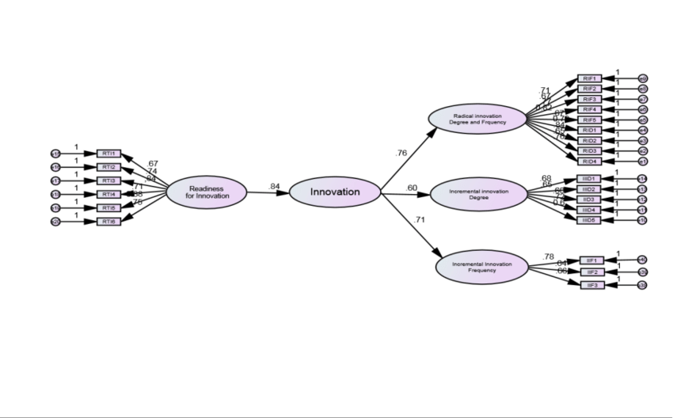

## Extensiones de SEM: Análisis de moderación de variables latentes

- Recursos: [**modsem**](https://modsem.org/index.html)

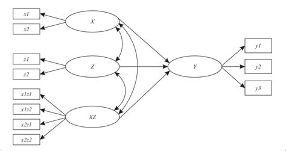

## Extensiones de SEM: Multilevel-SEM (Análisis de datos anidados)

- Recursos: [lavaan](https://lavaan.ugent.be/tutorial/multilevel.html)

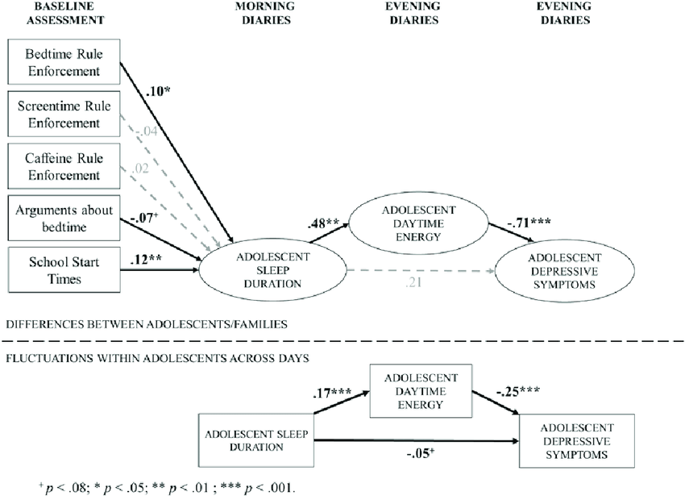

## Extensiones de SEM: **Cross-lagged panel models** (análisis longitudinales)

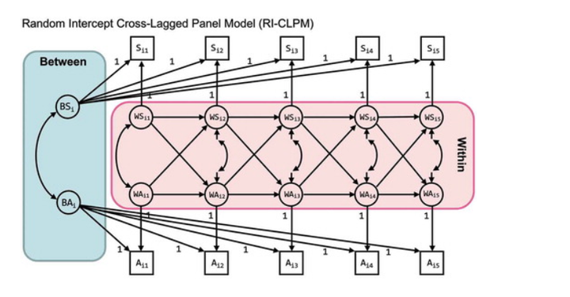

## En resumen

- SEM evalúa teorías, no sólo modelos
- El modelo es importante en la medida que representa la teoría
- Si se rechazan los modelos
  - Discutir la teoría
  - Revisar los modelos
- Replicar
- Balance entre tamaño de la muestra vs. complejidad del modelo
- SEM no resuelve problemas de diseño o de conceptualización
- SEM necesita
  - Diseño adecuado
  - Teoría/hipótesis sustantivas